# Replicability of Cronbach’s-alpha-if-removed item dropping decisions

#### What a replication’s verdict tells the researcher

1e and 1f condition on the truth, which the researcher never sees. The researcher sees the verdict, so the question they face is the reverse one: given that the replication did (or did not) show a gain, how likely is it that the drop was harmful? That depends on 1e and 1f and on how common harmful drops are to begin with, which is set by *k* and *N*. These are the predictive values of the replication as a check.

```r
rq1_verdict <- pairs_dropped_d |>
  mutate(harmful = delta_rho < 0,
         endorsed = gain_r > 0) |>
  group_by(k_indicators, n_participants) |>
  summarize(K_D                = n(),
            harm_overall       = mean(harmful),
            harm_overall_mcse  = proportion_mcse(harmful),
            K_endorsed         = sum(endorsed),
            harm_if_endorsed   = if (K_endorsed > 0) mean(harmful[endorsed]) else NA_real_,
            harm_if_endorsed_mcse = if (K_endorsed > 0) proportion_mcse(harmful[endorsed]) else NA_real_,
            K_not_endorsed     = sum(!endorsed),
            harm_if_not        = if (K_not_endorsed > 0) mean(harmful[!endorsed]) else NA_real_,
            harm_if_not_mcse   = if (K_not_endorsed > 0) proportion_mcse(harmful[!endorsed]) else NA_real_,
            .groups = "drop")

rq1_verdict |>
  mutate(harm_overall     = format_estimate(harm_overall, harm_overall_mcse),
         harm_if_endorsed = format_estimate(harm_if_endorsed, harm_if_endorsed_mcse),
         harm_if_not      = format_estimate(harm_if_not, harm_if_not_mcse)) |>
  select(k_indicators, n_participants, K_D, harm_overall,
         K_endorsed, harm_if_endorsed, K_not_endorsed, harm_if_not) |>
  kable(col.names = c("k", "N", "K_D", "P(harmful), all drops",
                      "K (endorsed)", "P(harmful | endorsed)",
                      "K (not endorsed)", "P(harmful | not endorsed)"),
        caption = "Probability that a drop truly reduced reliability, among all drops (equal to simulation 1's harm rate given drop), among drops a same-size replication endorsed (showed a gain), and among drops it did not, with +/-1 MCSE. NA marks cells with no drops in that group.") |>
  kable_classic(full_width = TRUE)
```

Probability that a drop truly reduced reliability, among all drops (equal to simulation 1's harm rate given drop), among drops a same-size replication endorsed (showed a gain), and among drops it did not, with +/-1 MCSE. NA marks cells with no drops in that group.

| k | N | K_D | P(harmful), all drops | K (endorsed) | P(harmful &#124; endorsed) | K (not endorsed) | P(harmful &#124; not endorsed) |
| --- | --- | --- | --- | --- | --- | --- | --- |
| 5 | 20 | 9102 | 0.467 (0.005) | 4583 | 0.261 (0.006) | 4519 | 0.676 (0.007) |
| 5 | 30 | 8868 | 0.394 (0.005) | 4952 | 0.198 (0.006) | 3916 | 0.641 (0.008) |
| 5 | 50 | 8560 | 0.331 (0.005) | 5295 | 0.155 (0.005) | 3265 | 0.615 (0.009) |
| 5 | 200 | 8013 | 0.160 (0.004) | 6371 | 0.060 (0.003) | 1642 | 0.549 (0.012) |
| 5 | 1000 | 7794 | 0.072 (0.003) | 7109 | 0.024 (0.002) | 685 | 0.574 (0.019) |
| 10 | 20 | 9874 | 0.320 (0.005) | 5768 | 0.160 (0.005) | 4106 | 0.546 (0.008) |
| 10 | 30 | 9838 | 0.269 (0.004) | 6287 | 0.126 (0.004) | 3551 | 0.522 (0.008) |
| 10 | 50 | 9750 | 0.198 (0.004) | 6999 | 0.079 (0.003) | 2751 | 0.503 (0.010) |
| 10 | 200 | 9641 | 0.076 (0.003) | 8509 | 0.025 (0.002) | 1132 | 0.466 (0.015) |
| 10 | 1000 | 9614 | 0.025 (0.002) | 9281 | 0.009 (0.001) | 333 | 0.483 (0.027) |
| 15 | 20 | 9982 | 0.250 (0.004) | 6424 | 0.116 (0.004) | 3558 | 0.492 (0.008) |
| 15 | 30 | 9978 | 0.190 (0.004) | 6967 | 0.084 (0.003) | 3011 | 0.436 (0.009) |
| 15 | 50 | 9970 | 0.128 (0.003) | 7834 | 0.049 (0.002) | 2136 | 0.419 (0.011) |
| 15 | 200 | 9939 | 0.037 (0.002) | 9256 | 0.012 (0.001) | 683 | 0.369 (0.018) |
| 15 | 1000 | 9919 | 0.008 (0.001) | 9779 | 0.003 (0.001) | 140 | 0.379 (0.041) |
| 20 | 20 | 9999 | 0.204 (0.004) | 6641 | 0.098 (0.004) | 3358 | 0.415 (0.009) |
| 20 | 30 | 9998 | 0.152 (0.004) | 7449 | 0.070 (0.003) | 2549 | 0.394 (0.010) |
| 20 | 50 | 9993 | 0.089 (0.003) | 8219 | 0.035 (0.002) | 1774 | 0.338 (0.011) |
| 20 | 200 | 9989 | 0.018 (0.001) | 9569 | 0.006 (0.001) | 420 | 0.281 (0.022) |
| 20 | 1000 | 9985 | 0.003 (0.001) | 9921 | 0.001 (0.000) | 64 | 0.344 (0.059) |
| 40 | 20 | 10000 | 0.120 (0.003) | 7380 | 0.055 (0.003) | 2620 | 0.304 (0.009) |
| 40 | 30 | 10000 | 0.070 (0.003) | 8172 | 0.028 (0.002) | 1828 | 0.257 (0.010) |
| 40 | 50 | 10000 | 0.032 (0.002) | 8921 | 0.012 (0.001) | 1079 | 0.199 (0.012) |
| 40 | 200 | 10000 | 0.001 (0.000) | 9898 | 0.000 (0.000) | 102 | 0.118 (0.032) |
| 40 | 1000 | 10000 | 0.000 (0.000) | 10000 | 0.000 (0.000) | 0 | NA |

#### Why the endorsement rate of harmful drops does not fall with sample size

If a replication’s ability to catch a harmful drop were fixed by the size of the harm, 1e would fall as *N* grows, because the replication’s sampling error shrinks. It does not, because the harmful drops are themselves selected by the rule: as *N* grows the rule stops making large harmful drops, and the ones it still makes are small. The table compares the mean true change in population alpha among harmful drops with the replication sample’s own sampling error of the gain, $\mathrm{SD}(G_R - \Delta_{\text{pop}})$. If their ratio is roughly constant across the design, the harmful drops that remain at any *N* sit at about the same distance from that *N*’s noise floor, and 1e should be roughly constant too. Population alpha is used here rather than true reliability because $G_R$ estimates the population alpha change, so that is the scale on which its noise is measured.

```r
rq1_harm_vs_noise <- pairs_dropped_d |>
  group_by(k_indicators, n_participants) |>
  summarize(K_harmful         = sum(delta_rho < 0),
            harm_alpha        = if (K_harmful > 0) mean(delta_pop[delta_rho < 0]) else NA_real_,
            harm_alpha_mcse   = if (K_harmful > 1) mean_mcse(delta_pop[delta_rho < 0]) else NA_real_,
            replication_noise = sd(gain_r - delta_pop),
            .groups = "drop") |>
  # descriptive ratio; no MCSE is given for it, since it is reported to show that it is
  # roughly constant across the design rather than as an estimate in its own right
  mutate(harm_to_noise = abs(harm_alpha) / replication_noise)

rq1_harm_vs_noise |>
  mutate(harm_alpha        = format_estimate(harm_alpha, harm_alpha_mcse, 0.0001),
         replication_noise = scales::number(replication_noise, accuracy = 0.0001),
         harm_to_noise     = if_else(is.na(harm_to_noise), "NA",
                                     scales::number(harm_to_noise, accuracy = 0.01))) |>
  select(k_indicators, n_participants, K_harmful, harm_alpha, replication_noise, harm_to_noise) |>
  kable(col.names = c("k", "N", "K (harmful drops)",
                      "Mean Delta_pop among harmful drops",
                      "Replication noise SD(G_R - Delta_pop)", "|Harm| / noise"),
        caption = "Size of the harm among harmful drops, on the population-alpha scale (+/-1 MCSE), against the sampling error of the replication gain at the same sample size, and their ratio. A roughly constant ratio means the harmful drops the rule still makes at any N are about equally hard for a same-size replication to detect. NA marks the condition with no harmful drops.") |>
  kable_classic(full_width = TRUE)
```

Size of the harm among harmful drops, on the population-alpha scale (+/-1 MCSE), against the sampling error of the replication gain at the same sample size, and their ratio. A roughly constant ratio means the harmful drops the rule still makes at any N are about equally hard for a same-size replication to detect. NA marks the condition with no harmful drops.

| k | N | K (harmful drops) | Mean Delta_pop among harmful drops | Replication noise SD(G_R - Delta_pop) | &#124;Harm&#124; / noise |
| --- | --- | --- | --- | --- | --- |
| 5 | 20 | 4252 | -0.0440 (0.0005) | 0.1203 | 0.37 |
| 5 | 30 | 3490 | -0.0384 (0.0005) | 0.0876 | 0.44 |
| 5 | 50 | 2830 | -0.0306 (0.0005) | 0.0638 | 0.48 |
| 5 | 200 | 1282 | -0.0150 (0.0004) | 0.0293 | 0.51 |
| 5 | 1000 | 563 | -0.0054 (0.0003) | 0.0131 | 0.41 |
| 10 | 20 | 3164 | -0.0123 (0.0002) | 0.0369 | 0.33 |
| 10 | 30 | 2646 | -0.0099 (0.0002) | 0.0270 | 0.37 |
| 10 | 50 | 1935 | -0.0081 (0.0002) | 0.0192 | 0.42 |
| 10 | 200 | 737 | -0.0038 (0.0001) | 0.0090 | 0.43 |
| 10 | 1000 | 243 | -0.0014 (0.0001) | 0.0041 | 0.35 |
| 15 | 20 | 2495 | -0.0053 (0.0001) | 0.0178 | 0.30 |
| 15 | 30 | 1900 | -0.0043 (0.0001) | 0.0131 | 0.33 |
| 15 | 50 | 1279 | -0.0036 (0.0001) | 0.0094 | 0.38 |
| 15 | 200 | 363 | -0.0016 (0.0001) | 0.0045 | 0.36 |
| 15 | 1000 | 78 | -0.0006 (0.0001) | 0.0020 | 0.31 |
| 20 | 20 | 2041 | -0.0029 (0.0001) | 0.0107 | 0.27 |
| 20 | 30 | 1523 | -0.0024 (0.0001) | 0.0079 | 0.31 |
| 20 | 50 | 886 | -0.0018 (0.0001) | 0.0055 | 0.33 |
| 20 | 200 | 178 | -0.0008 (0.0001) | 0.0026 | 0.31 |
| 20 | 1000 | 33 | -0.0004 (0.0001) | 0.0012 | 0.34 |
| 40 | 20 | 1201 | -0.0007 (0.0000) | 0.0028 | 0.25 |
| 40 | 30 | 700 | -0.0006 (0.0000) | 0.0021 | 0.28 |
| 40 | 50 | 323 | -0.0005 (0.0000) | 0.0016 | 0.29 |
| 40 | 200 | 13 | -0.0002 (0.0000) | 0.0007 | 0.31 |
| 40 | 1000 | 0 | NA | 0.0003 | NA |

#### Classifying drops by population alpha instead of true reliability

Harmful and helpful drops are classified above by the true reliability change, so that “harmful” means what it means in simulation 1. Classifying by the population alpha change instead is the natural alternative, since $G_R$ estimates that change. The two signs disagree for few drops overall, but harmful drops become rare at large *N*, so the disagreements make up a larger share of the harmful drops there. The table reports that share and the endorsement rates under the alternative classification, to show whether it changes 1e and 1f.

```r
rq1_by_population_alpha <- pairs_dropped_d |>
  group_by(k_indicators, n_participants) |>
  summarize(disagree_all_drops      = mean(sign(delta_pop) != sign(delta_rho)),
            K_harmful               = sum(delta_rho < 0),
            harmful_raising_alpha   = if (K_harmful > 0) mean(delta_pop[delta_rho < 0] > 0) else NA_real_,
            K_alpha_down            = sum(delta_pop < 0),
            endorse_alpha_down      = if (K_alpha_down > 0) mean(gain_r[delta_pop < 0] > 0) else NA_real_,
            endorse_alpha_down_mcse = if (K_alpha_down > 0) proportion_mcse(gain_r[delta_pop < 0] > 0) else NA_real_,
            K_alpha_up              = sum(delta_pop > 0),
            endorse_alpha_up        = if (K_alpha_up > 0) mean(gain_r[delta_pop > 0] > 0) else NA_real_,
            endorse_alpha_up_mcse   = if (K_alpha_up > 0) proportion_mcse(gain_r[delta_pop > 0] > 0) else NA_real_,
            .groups = "drop") |>
  left_join(rq1_operating |> select(k_indicators, n_participants, endorse_harmful, endorse_helpful),
            by = c("k_indicators", "n_participants"))

rq1_by_population_alpha |>
  mutate(disagree_all_drops    = scales::percent(disagree_all_drops, accuracy = 0.1),
         harmful_raising_alpha = if_else(is.na(harmful_raising_alpha), "NA",
                                         scales::percent(harmful_raising_alpha, accuracy = 0.1)),
         endorse_alpha_down    = format_estimate(endorse_alpha_down, endorse_alpha_down_mcse),
         endorse_alpha_up      = format_estimate(endorse_alpha_up, endorse_alpha_up_mcse),
         endorse_harmful       = if_else(is.na(endorse_harmful), "NA",
                                         scales::number(endorse_harmful, accuracy = 0.001)),
         endorse_helpful       = scales::number(endorse_helpful, accuracy = 0.001)) |>
  select(k_indicators, n_participants, disagree_all_drops, harmful_raising_alpha,
         endorse_harmful, endorse_alpha_down, endorse_helpful, endorse_alpha_up) |>
  kable(col.names = c("k", "N", "Signs disagree (% of drops)",
                      "Harmful drops that raise population alpha (%)",
                      "1e (by reliability)", "1e (by population alpha)",
                      "1f (by reliability)", "1f (by population alpha)"),
        caption = "Sensitivity of 1e and 1f to how drops are classified. 'Signs disagree' is the share of all drops whose population alpha change and true reliability change have opposite signs. The endorsement rates are shown under the main classification (true reliability) and the alternative (population alpha), the latter with +/-1 MCSE. NA marks the condition with no harmful drops.") |>
  kable_classic(full_width = TRUE)
```

Sensitivity of 1e and 1f to how drops are classified. 'Signs disagree' is the share of all drops whose population alpha change and true reliability change have opposite signs. The endorsement rates are shown under the main classification (true reliability) and the alternative (population alpha), the latter with +/-1 MCSE. NA marks the condition with no harmful drops.

| k | N | Signs disagree (% of drops) | Harmful drops that raise population alpha (%) | 1e (by reliability) | 1e (by population alpha) | 1f (by reliability) | 1f (by population alpha) |
| --- | --- | --- | --- | --- | --- | --- | --- |
| 5 | 20 | 2.2% | 1.7% | 0.282 | 0.285 (0.007) | 0.698 | 0.700 (0.007) |
| 5 | 30 | 2.4% | 2.2% | 0.281 | 0.283 (0.008) | 0.739 | 0.742 (0.006) |
| 5 | 50 | 2.5% | 3.4% | 0.290 | 0.291 (0.009) | 0.781 | 0.782 (0.005) |
| 5 | 200 | 2.0% | 6.0% | 0.297 | 0.296 (0.013) | 0.890 | 0.891 (0.004) |
| 5 | 1000 | 2.2% | 21.0% | 0.302 | 0.254 (0.020) | 0.960 | 0.957 (0.002) |
| 10 | 20 | 1.3% | 0.6% | 0.291 | 0.299 (0.008) | 0.722 | 0.725 (0.005) |
| 10 | 30 | 1.4% | 1.3% | 0.299 | 0.303 (0.009) | 0.764 | 0.767 (0.005) |
| 10 | 50 | 1.1% | 1.7% | 0.284 | 0.289 (0.010) | 0.825 | 0.827 (0.004) |
| 10 | 200 | 0.6% | 5.2% | 0.284 | 0.283 (0.017) | 0.932 | 0.931 (0.003) |
| 10 | 1000 | 0.4% | 14.4% | 0.337 | 0.310 (0.032) | 0.982 | 0.980 (0.001) |
| 15 | 20 | 1.1% | 0.6% | 0.298 | 0.303 (0.009) | 0.759 | 0.762 (0.005) |
| 15 | 30 | 0.7% | 0.7% | 0.309 | 0.313 (0.011) | 0.790 | 0.792 (0.005) |
| 15 | 50 | 0.7% | 1.5% | 0.301 | 0.303 (0.013) | 0.857 | 0.859 (0.004) |
| 15 | 200 | 0.4% | 5.8% | 0.306 | 0.308 (0.024) | 0.955 | 0.955 (0.002) |
| 15 | 1000 | 0.1% | 14.1% | 0.321 | 0.328 (0.057) | 0.991 | 0.990 (0.001) |
| 20 | 20 | 1.1% | 0.5% | 0.318 | 0.324 (0.010) | 0.753 | 0.756 (0.005) |
| 20 | 30 | 0.7% | 0.7% | 0.341 | 0.344 (0.012) | 0.818 | 0.820 (0.004) |
| 20 | 50 | 0.7% | 1.4% | 0.324 | 0.334 (0.015) | 0.871 | 0.873 (0.004) |
| 20 | 200 | 0.1% | 6.7% | 0.337 | 0.333 (0.036) | 0.969 | 0.969 (0.002) |
| 20 | 1000 | 0.0% | 12.1% | 0.333 | 0.276 (0.083) | 0.996 | 0.996 (0.001) |
| 40 | 20 | 0.6% | 0.0% | 0.337 | 0.346 (0.013) | 0.793 | 0.795 (0.004) |
| 40 | 30 | 0.4% | 0.3% | 0.330 | 0.332 (0.017) | 0.854 | 0.856 (0.004) |
| 40 | 50 | 0.3% | 0.9% | 0.334 | 0.341 (0.026) | 0.911 | 0.912 (0.003) |
| 40 | 200 | 0.0% | 0.0% | 0.077 | 0.200 (0.103) | 0.991 | 0.991 (0.001) |
| 40 | 1000 | 0.0% | NA | NA | NA | 1.000 | 1.000 (0.000) |

### What a single replication can show

The spread of $G_R$ across pairs, not the precision of its mean: each pair is an independently simulated discovery-and-replication study, so the 2.5th and 97.5th percentiles estimate the range a single replication can show. As in simulation 1, the interval marginalises over both the item pool and the samples drawn from it. The discovery gain is shown alongside for comparison.

```r
rq1_spread <- pairs_dropped_d |>
  select(k_indicators, n_participants, gain_d, gain_r) |>
  pivot_longer(cols = c(gain_d, gain_r), names_to = "quantity", values_to = "value") |>
  group_by(k_indicators, n_participants, quantity) |>
  summarize(median        = median(value),
            pi_lower      = unname(quantile(value, 0.025)),
            pi_lower_mcse = quantile_mcse(value, 0.025),
            pi_upper      = unname(quantile(value, 0.975)),
            pi_upper_mcse = quantile_mcse(value, 0.975),
            .groups = "drop") |>
  mutate(quantity = factor(quantity, levels = c("gain_d", "gain_r"),
                           labels = c("Discovery gain (G_D)", "1g. Replication gain (G_R)")))

rq1_spread |>
  mutate(interval = paste0("[", format_estimate(pi_lower, pi_lower_mcse, 0.0001), ", ",
                           format_estimate(pi_upper, pi_upper_mcse, 0.0001), "]"),
         median = scales::number(median, accuracy = 0.0001)) |>
  select(k_indicators, n_participants, quantity, median, interval) |>
  pivot_wider(names_from = quantity, values_from = c(median, interval)) |>
  select(k_indicators, n_participants,
         `median_Discovery gain (G_D)`, `interval_Discovery gain (G_D)`,
         `median_1g. Replication gain (G_R)`, `interval_1g. Replication gain (G_R)`) |>
  kable(col.names = c("k", "N", "G_D median", "G_D 95% PI",
                      "G_R median", "1g. G_R 95% PI"),
        caption = "95% prediction intervals (bound MCSE in parentheses) and medians of the discovery and replication gains, among pairs in which the discovery sample dropped an item.") |>
  kable_classic(full_width = TRUE)
```

95% prediction intervals (bound MCSE in parentheses) and medians of the discovery and replication gains, among pairs in which the discovery sample dropped an item.

| k | N | G_D median | G_D 95% PI | G_R median | 1g. G_R 95% PI |
| --- | --- | --- | --- | --- | --- |
| 5 | 20 | 0.0692 | [0.0035 (0.0002), 0.3694 (0.0066)] | 0.0007 | [-0.2672 (0.0086), 0.3128 (0.0078)] |
| 5 | 30 | 0.0599 | [0.0033 (0.0002), 0.2994 (0.0061)] | 0.0115 | [-0.1891 (0.0056), 0.2564 (0.0058)] |
| 5 | 50 | 0.0514 | [0.0023 (0.0002), 0.2371 (0.0045)] | 0.0197 | [-0.1299 (0.0030), 0.2239 (0.0043)] |
| 5 | 200 | 0.0414 | [0.0020 (0.0001), 0.1766 (0.0037)] | 0.0333 | [-0.0462 (0.0018), 0.1734 (0.0033)] |
| 5 | 1000 | 0.0379 | [0.0020 (0.0002), 0.1649 (0.0025)] | 0.0367 | [-0.0122 (0.0008), 0.1634 (0.0026)] |
| 10 | 20 | 0.0312 | [0.0032 (0.0002), 0.1387 (0.0031)] | 0.0059 | [-0.0664 (0.0017), 0.1061 (0.0027)] |
| 10 | 30 | 0.0269 | [0.0026 (0.0002), 0.1102 (0.0014)] | 0.0088 | [-0.0452 (0.0013), 0.0893 (0.0018)] |
| 10 | 50 | 0.0234 | [0.0023 (0.0001), 0.0850 (0.0011)] | 0.0119 | [-0.0302 (0.0006), 0.0790 (0.0015)] |
| 10 | 200 | 0.0192 | [0.0018 (0.0001), 0.0661 (0.0008)] | 0.0166 | [-0.0090 (0.0003), 0.0627 (0.0009)] |
| 10 | 1000 | 0.0183 | [0.0015 (0.0001), 0.0625 (0.0010)] | 0.0177 | [-0.0009 (0.0002), 0.0629 (0.0010)] |
| 15 | 20 | 0.0187 | [0.0032 (0.0001), 0.0750 (0.0015)] | 0.0053 | [-0.0273 (0.0007), 0.0550 (0.0012)] |
| 15 | 30 | 0.0163 | [0.0030 (0.0001), 0.0565 (0.0007)] | 0.0062 | [-0.0189 (0.0005), 0.0470 (0.0008)] |
| 15 | 50 | 0.0143 | [0.0024 (0.0001), 0.0458 (0.0007)] | 0.0082 | [-0.0122 (0.0004), 0.0411 (0.0007)] |
| 15 | 200 | 0.0116 | [0.0019 (0.0001), 0.0353 (0.0004)] | 0.0101 | [-0.0026 (0.0001), 0.0347 (0.0004)] |
| 15 | 1000 | 0.0114 | [0.0018 (0.0001), 0.0331 (0.0005)] | 0.0110 | [0.0009 (0.0001), 0.0332 (0.0004)] |
| 20 | 20 | 0.0129 | [0.0029 (0.0001), 0.0472 (0.0009)] | 0.0036 | [-0.0157 (0.0004), 0.0333 (0.0006)] |
| 20 | 30 | 0.0110 | [0.0026 (0.0001), 0.0353 (0.0005)] | 0.0046 | [-0.0100 (0.0003), 0.0295 (0.0004)] |
| 20 | 50 | 0.0097 | [0.0024 (0.0001), 0.0278 (0.0004)] | 0.0057 | [-0.0059 (0.0002), 0.0252 (0.0004)] |
| 20 | 200 | 0.0080 | [0.0019 (0.0001), 0.0214 (0.0003)] | 0.0070 | [-0.0008 (0.0001), 0.0208 (0.0003)] |
| 20 | 1000 | 0.0077 | [0.0017 (0.0000), 0.0202 (0.0002)] | 0.0075 | [0.0010 (0.0001), 0.0202 (0.0002)] |
| 40 | 20 | 0.0044 | [0.0015 (0.0000), 0.0135 (0.0002)] | 0.0015 | [-0.0034 (0.0001), 0.0094 (0.0002)] |
| 40 | 30 | 0.0039 | [0.0014 (0.0000), 0.0101 (0.0002)] | 0.0018 | [-0.0021 (0.0001), 0.0082 (0.0001)] |
| 40 | 50 | 0.0034 | [0.0013 (0.0000), 0.0082 (0.0001)] | 0.0021 | [-0.0012 (0.0000), 0.0074 (0.0001)] |
| 40 | 200 | 0.0029 | [0.0011 (0.0000), 0.0063 (0.0001)] | 0.0026 | [0.0003 (0.0000), 0.0062 (0.0001)] |
| 40 | 1000 | 0.0027 | [0.0011 (0.0000), 0.0058 (0.0000)] | 0.0027 | [0.0009 (0.0000), 0.0057 (0.0001)] |

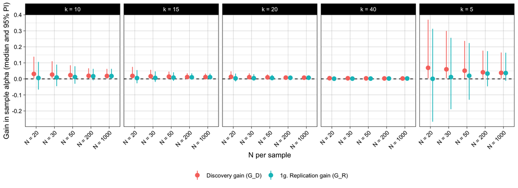

```r
rq1_spread |>
  label_sample_sizes() |>
  ggplot(aes(x = n_label, y = median, color = quantity)) +
  geom_hline(yintercept = 0, linetype = "dashed") +
  geom_pointrange(aes(ymin = pi_lower, ymax = pi_upper),
                  position = position_dodge(width = 0.5)) +
  facet_wrap(~ paste0("k = ", k_indicators), nrow = 1) +
  scale_y_continuous(name = "Gain in sample alpha (median and 95% PI)",
                     breaks = breaks_pretty(n = 6)) +
  xlab("N per sample") +
  theme_linedraw() +
  theme(axis.text.x = element_text(angle = 45, hjust = 1),
        legend.position = "bottom") +
  guides(color = guide_legend(title = NULL))
```

## RQ2 — does the item choice replicate?

```r
rq2_summary <- pairs_dropped_both |>
  group_by(k_indicators, n_participants) |>
  summarize(K_DR = n(),
            agreement      = mean(same_item),
            agreement_mcse = proportion_mcse(same_item),
            .groups = "drop") |>
  mutate(floor = 1 / k_indicators,
         chance_corrected      = (agreement - floor) / (1 - floor),
         chance_corrected_mcse = agreement_mcse / (1 - floor))

rq2_summary |>
  mutate(agreement        = format_estimate(agreement, agreement_mcse),
         chance_corrected = format_estimate(chance_corrected, chance_corrected_mcse),
         floor            = scales::number(floor, accuracy = 0.001)) |>
  select(k_indicators, n_participants, K_DR, agreement, floor, chance_corrected) |>
  kable(col.names = c("k", "N", "K_DR", "2. P(same item)", "Floor 1/k",
                      "Chance-corrected (A - 1/k) / (1 - 1/k)"),
        caption = "RQ2, among pairs in which both samples dropped an item: proportion dropping the same item (MCSE), its floor, and the chance-corrected agreement (0 = no better than random, 1 = always the same item).") |>
  kable_classic(full_width = TRUE)
```

RQ2, among pairs in which both samples dropped an item: proportion dropping the same item (MCSE), its floor, and the chance-corrected agreement (0 = no better than random, 1 = always the same item).

| k | N | K_DR | 2. P(same item) | Floor 1/k | Chance-corrected (A - 1/k) / (1 - 1/k) |
| --- | --- | --- | --- | --- | --- |
| 5 | 20 | 8336 | 0.422 (0.005) | 0.200 | 0.278 (0.007) |
| 5 | 30 | 7984 | 0.503 (0.006) | 0.200 | 0.379 (0.007) |
| 5 | 50 | 7558 | 0.594 (0.006) | 0.200 | 0.493 (0.007) |
| 5 | 200 | 7163 | 0.819 (0.005) | 0.200 | 0.773 (0.006) |
| 5 | 1000 | 7275 | 0.931 (0.003) | 0.200 | 0.914 (0.004) |
| 10 | 20 | 9789 | 0.324 (0.005) | 0.100 | 0.249 (0.005) |
| 10 | 30 | 9674 | 0.386 (0.005) | 0.100 | 0.318 (0.006) |
| 10 | 50 | 9530 | 0.490 (0.005) | 0.100 | 0.433 (0.006) |
| 10 | 200 | 9396 | 0.711 (0.005) | 0.100 | 0.679 (0.005) |
| 10 | 1000 | 9472 | 0.868 (0.003) | 0.100 | 0.853 (0.004) |
| 15 | 20 | 9970 | 0.292 (0.005) | 0.067 | 0.242 (0.005) |
| 15 | 30 | 9958 | 0.343 (0.005) | 0.067 | 0.296 (0.005) |
| 15 | 50 | 9943 | 0.442 (0.005) | 0.067 | 0.402 (0.005) |
| 15 | 200 | 9887 | 0.663 (0.005) | 0.067 | 0.639 (0.005) |
| 15 | 1000 | 9883 | 0.842 (0.004) | 0.067 | 0.831 (0.004) |
| 20 | 20 | 9997 | 0.254 (0.004) | 0.050 | 0.215 (0.005) |
| 20 | 30 | 9992 | 0.322 (0.005) | 0.050 | 0.286 (0.005) |
| 20 | 50 | 9989 | 0.405 (0.005) | 0.050 | 0.374 (0.005) |
| 20 | 200 | 9979 | 0.635 (0.005) | 0.050 | 0.616 (0.005) |
| 20 | 1000 | 9977 | 0.822 (0.004) | 0.050 | 0.813 (0.004) |
| 40 | 20 | 10000 | 0.190 (0.004) | 0.025 | 0.169 (0.004) |
| 40 | 30 | 10000 | 0.257 (0.004) | 0.025 | 0.238 (0.004) |
| 40 | 50 | 10000 | 0.337 (0.005) | 0.025 | 0.320 (0.005) |
| 40 | 200 | 10000 | 0.591 (0.005) | 0.025 | 0.581 (0.005) |
| 40 | 1000 | 10000 | 0.798 (0.004) | 0.025 | 0.793 (0.004) |

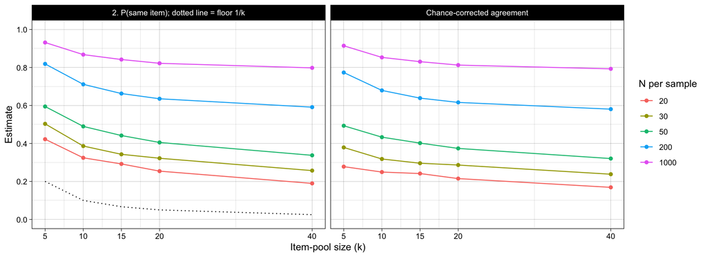

```r
rq2_plot_data <- rq2_summary |>
  stack_estimates(c("agreement", "chance_corrected")) |>
  mutate(quantity = factor(quantity, levels = c("agreement", "chance_corrected"),
                           labels = c("2. P(same item); dotted line = floor 1/k",
                                      "Chance-corrected agreement")))

floor_line <- tibble(k_indicators = k_levels, estimate = 1 / k_levels,
                     quantity = factor("2. P(same item); dotted line = floor 1/k",
                                       levels = levels(rq2_plot_data$quantity)))

ggplot(rq2_plot_data, aes(x = k_indicators, y = estimate, color = as.factor(n_participants))) +
  geom_line(data = floor_line, aes(x = k_indicators, y = estimate),
            inherit.aes = FALSE, linetype = "dotted") +
  geom_linerange(aes(ymin = estimate - mcse, ymax = estimate + mcse), color = "black") +
  geom_line() +
  geom_point() +
  facet_wrap(~ quantity) +
  scale_x_continuous(name = "Item-pool size (k)", breaks = k_levels) +
  scale_y_continuous(name = "Estimate", limits = c(0, 1), breaks = breaks_pretty(n = 6)) +
  theme_linedraw() +
  guides(color = guide_legend(title = "N per sample"))
```